# Anatomy of a Seurat Object

Spatial transcriptomics

Seurat

Assays

Layers

Inspect the internal structure of a Seurat object, including assays, reductions, metadata, and spatial image slots. This aside teaches you how to safely explore and edit these components to comfortably work within the Seurat workflow.

Author

Noor Sohail

Published

April 15, 2026

Keywords

meta.data, Metadata, Data structure

Approximate time: 10 minutes

## Learning objectives

In this lesson, we will:

- Use the assay functionality of Seurat to store multiple counts matrices
- Access counts matrices and spatial coordinates
- Update default representations of data

## Overview of lesson

At first glance, the Seurat object may appear scary due to the large amount of information that is stored within a single variables. Throughout this lesson, we will walk through the different slots and components of a Seurat object to better familiarize ourselves with how to access and manipulate data stored within a Seurat object.

## Load dataset

```r
library(Seurat)
library(tidyverse)
crc <- Load10X_Spatial(data.dir = "data/P5CRC_cropped/",
                       bin.size = c(8, 16),
                       slice = "P5CRC")
```

## Anatomy of a Seurat object

As we can see from our Seurat callout, there are a lot of different slots inside our object. Here, we will go through each of the major components of a Seurat object and how you would access key pieces of information.

### Assays

`Assays` are where we can store different counts matrices - we are not forced to keep the same features and variable genes across assays. Each assay will contain it’s own `Layers` that can be distinct from other assays in the object. This is useful in several different cases:

- Multi-modal assays, where you can keep the expression matrices for RNA, ATAC, or protein in a single Seurat object
- Storing counts matrices from a variety of different normalization techniques
- Batch integration methods will sometimes generate a transformed counts matrix

Here we can print the different assays that exist within our `crc` object:

```r
Assays(crc)
```

```
[1] "Spatial.008um" "Spatial.016um"
```

We have 2 distinct assays for the different bin sizes, which makes sense because we have different count matrices for our cells based upon the bin size that was selected.

The `DefaultAssay()` function shows us which assay information will be used in other Seurat function calls, unless explicitly specified otherwise.

```r
DefaultAssay(crc)
```

```
[1] "Spatial.008um"
```

We can also change what our default assay is. Let’s set it to the `016um` bins:

```r
DefaultAssay(crc) <- "Spatial.016um"
crc
```

```
An object of class Seurat
36170 features across 97570 samples within 2 assays
Active assay: Spatial.016um (18085 features, 0 variable features)
 1 layer present: counts
 1 other assay present: Spatial.008um
 2 spatial fields of view present: P5CRC.008um P5CRC.016um
```

Now we see that the callout says: `Active assay: Spatial.016um`

### `Features` and `Cells`

Our count matrices function as any other matrix does, with rows and columns.

In Seurat, the **rows** correspond to `Features`. In the case of spatial transcriptomics, our features are genes. In other experiments, features could refer to chromatin peaks or proteins. The important thing to keep in mind is what technology you are using. Since this is a Visium HD dataset, we are quantifying RNA expression (genes).

We can see what the first few genes/features in our count matrix are:

```r
Features(crc) %>% head()
```

```
[1] "SAMD11"  "NOC2L"   "KLHL17"  "PLEKHN1" "PERM1"   "HES4"
```

As well as see the number of genes that are found in each of our assays:

```r
nrow(crc[["Spatial.008um"]])
```

```
[1] 18085
```

```r
nrow(crc[["Spatial.016um"]])
```

```
[1] 18085
```

The **columns** correspond to `Cells` (or samples as it appears in the callout). We can see what the first few cells in our count matrix are:

```r
Cells(crc) %>% head()
```

```
[1] "s_016um_00050_00315-1" "s_016um_00064_00214-1" "s_016um_00101_00317-1"
[4] "s_016um_00049_00195-1" "s_016um_00032_00133-1" "s_016um_00061_00268-1"
```

As well as see the number of cells that are found in each of our assays:

```r
ncol(crc[["Spatial.008um"]])
```

```
[1] 77896
```

```r
ncol(crc[["Spatial.016um"]])
```

```
[1] 19674
```

### Layers

Layers are our count matrices.

```r
Layers(crc)
```

```
[1] "counts"
```

By default, Seurat uses the following naming convention for the counts matrices within an `Assay`:

Table 1: Description of each `Layer()` count matrix

| Layer | Description |
| --- | --- |
| counts | Raw counts |
| data | Normalized counts |
| scale.data | Scaled‑normalized counts |

You may notice that our Seurat object only contains `counts` right now. This is because we have not run any normalization steps yet (we will discuss how to do so in future lessons).

Using the `LayerData()` function we can access the entire counts matrix. Furthermore, we can specify the `assay` if we would prefer to not use the `DefaultAssay`.

```r
LayerData(crc,
          assay = "Spatial.016um",
          layer = "count")[1:5, 1:5]
```

Table 2: First 5 rows and columns of raw counts matrix

|  | s_016um_00050_00315-1 | s_016um_00064_00214-1 | s_016um_00101_00317-1 | s_016um_00049_00195-1 | s_016um_00032_00133-1 |
| --- | --- | --- | --- | --- | --- |
| SAMD11 | 0 | 0 | 0 | 0 | 0 |
| NOC2L | 0 | 0 | 0 | 0 | 0 |
| KLHL17 | 0 | 0 | 0 | 0 | 0 |
| PLEKHN1 | 0 | 0 | 0 | 0 | 0 |
| PERM1 | 0 | 0 | 0 | 0 | 0 |

By printing the first 5 features and cells in our object (for easier visualization). We can see that we are working with **whole numbers** which reinforces the idea that this is the **raw data**, with no transformations having been applied.

### Spatial fields

We do not just have expression data associated with our sample, we also have the spatial slide that comes with its own set of values and information.

For example we can grab the x,y coordinates of each bin using the `GetTissueCoordinates()` function.

```r
GetTissueCoordinates(crc) %>% View()
```

Table 3: Coordinates on spatial slide for each cell

|  | x | y | cell |
| --- | --- | --- | --- |
| s_016um_00050_00315-1 | 62715.76 | 61103.62 | s_016um_00050_00315-1 |
| s_016um_00064_00214-1 | 56816.46 | 60261.12 | s_016um_00064_00214-1 |
| s_016um_00101_00317-1 | 62844.88 | 58123.60 | s_016um_00101_00317-1 |
| s_016um_00049_00195-1 | 55702.46 | 61133.16 | s_016um_00049_00195-1 |
| s_016um_00032_00133-1 | 52074.99 | 62111.72 | s_016um_00032_00133-1 |

Or visualize what our slide looks like with `SpatialDimPlot()`:

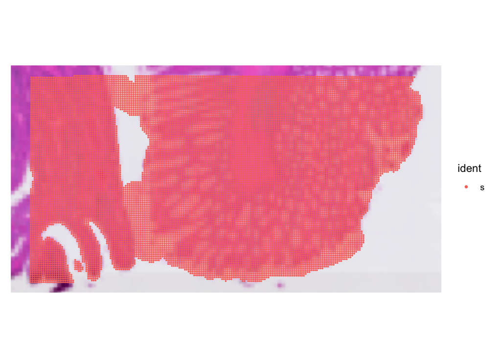

Figure 1: Spatial visualization of spots with `SpatialDimPlot()`

```r
SpatialDimPlot(crc, pt.size.factor = 7)
```

### Metadata

**Seurat automatically creates some metadata** for each of the cells when the object is created. This information is stored in the `@meta.data` slot within the Seurat object. The rownames are automatically set to be the cell names.

```r
crc@meta.data %>% View()
```

Table 4: Seurat default `@meta.data`

|  | orig.ident | nCount_Spatial.008um | nFeature_Spatial.008um | nCount_Spatial.016um | nFeature_Spatial.016um |
| --- | --- | --- | --- | --- | --- |
| s_008um_00078_00444-1 | s | 65 | 57 | NA | NA |
| s_008um_00128_00278-1 | s | 1300 | 906 | NA | NA |
| s_008um_00052_00559-1 | s | 128 | 121 | NA | NA |
| s_008um_00121_00413-1 | s | 538 | 326 | NA | NA |
| s_008um_00167_00326-1 | s | 44 | 39 | NA | NA |

What does each column represent?

Table 5: Columns automatically populated in `@meta.data`

| Column | Description |
| --- | --- |
| orig.ident | Sample identity if known; defaults to “s” |
| nCount_RNA | Number of UMIs per cell |
| nFeature_RNA | Number of genes detected per cell |

While it may seem intimidating at first, the important thing to remember is that this is a dataframe. Therefore can modify and work with this dataframe just like we would any other in R! For example, we can set our `orig.ident` column to be our sample name rather than “s”.

```r
crc@meta.data$orig.ident <- "P5CRC"
```

```r
crc@meta.data %>% View()
```

Table 6: Seurat default `@meta.data` after updating `orig.ident`

|  | orig.ident | nCount_Spatial.008um | nFeature_Spatial.008um | nCount_Spatial.016um | nFeature_Spatial.016um |
| --- | --- | --- | --- | --- | --- |
| s_008um_00078_00444-1 | P5CRC | 65 | 57 | NA | NA |
| s_008um_00128_00278-1 | P5CRC | 1300 | 906 | NA | NA |
| s_008um_00052_00559-1 | P5CRC | 128 | 121 | NA | NA |
| s_008um_00121_00413-1 | P5CRC | 538 | 326 | NA | NA |
| s_008um_00167_00326-1 | P5CRC | 44 | 39 | NA | NA |

Additionally, we do not have use the `@meta.data` each time we want to access a single column. We can use the `$` follow by the column name as a shorthand.

```r
crc$nCount_Spatial.008um %>% head()
```

```
s_008um_00078_00444-1 s_008um_00128_00278-1 s_008um_00052_00559-1
                   65                  1300                   128
s_008um_00121_00413-1 s_008um_00167_00326-1 s_008um_00202_00633-1
                  538                    44                   365
```

### Idents

The cell identities are stored as `Idents()`, which contain the default way to label cells. For example, if we wanted to label each cell by which sample they came from we could run:

```r
Idents(crc) <- "orig.ident"
Idents(crc) %>% head()
```

```
s_008um_00078_00444-1 s_008um_00128_00278-1 s_008um_00052_00559-1
                P5CRC                 P5CRC                 P5CRC
s_008um_00121_00413-1 s_008um_00167_00326-1 s_008um_00202_00633-1
                P5CRC                 P5CRC                 P5CRC
Levels: P5CRC
```

Where we see that the identities of the cells are the value stored in the `@meta.data` column `orig.ident`.

Back to Lesson >>

Back to Schedule